# act_report

## Report: act_report ( Analysis and Visualizations)

### INTRODUCTION

This act report includes the basic data analysis of WeRateDogs twitter account data. It provides four insights from the analysis and visualization results.

### Data Analysis and Visualization

#### What were the main tweet distribution source?

- Twitter for iPhone 1635
- Twitter Web Client 22
- TweetDeck 9
- Vine - Make a Scene 0

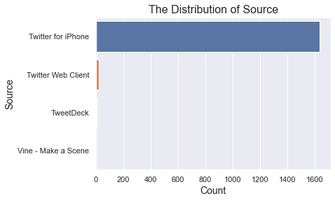

#### What is the most common dog stage?

From our analysis, pupper had the highest value count for dog stage in terms of favourite counts

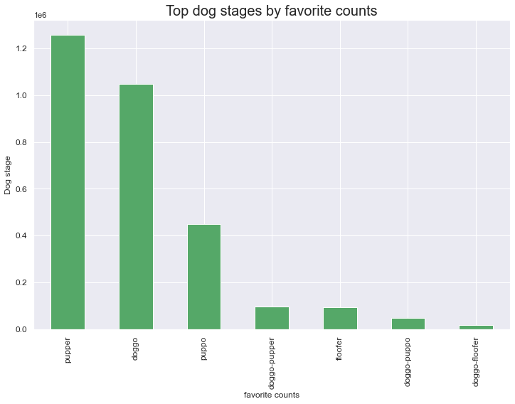

#### What is the most common dog breed ?

From our analysis we observed that golden_retriever was the most common dog breed. They had the highest value counts.

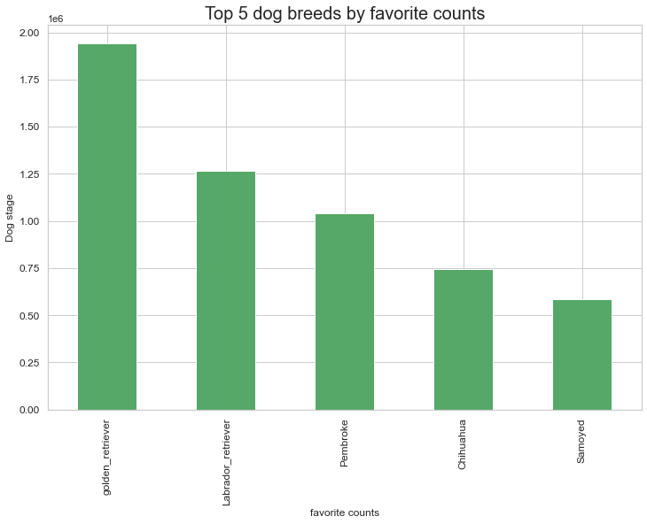

#### What is the correlation between retweet count and favorite count?

A reasonable hypothesis is that most popular tweets usually get a large number of retweets and favorite counts. I tested the correlation between ‘retweet_count’ and ‘favorite_count’. And it showed that there was a strong positive relationship between ‘retweet_count’ and ‘favorite_count’. The plot below confirms this hypothesis.

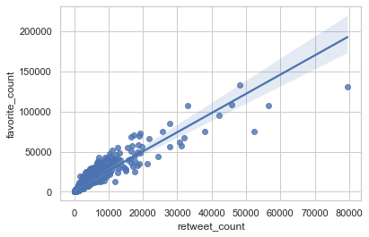

#### What is the change of retweets count and favorite count by time?

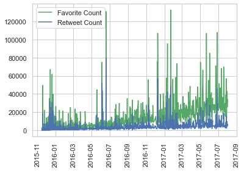